# SIMULACIÓN Y TEORÍA DE LA DECISIÓN

### Ejercicio 2

En un restaurante de **la ciudad** se sabe que la probabilidad de que se reciba un billete de 50.000 falso es de 0.015. Si se sabe que en una semana se reciben pagos con 900 billetes de 50.000, halle la probabilidad de que:

1. A lo sumo 25 billetes sean falsos.
2. La cantidad de billetes falsos esté entre 20 y 30.
3. Más de 10 sean falsos.

```
## P(x<=25) es de:  0.9985199
```

```
## El 99.852% de los billetes de 50.000, salen a lo sumo 25 billetes falsos
```

```
## p(20< x <30) es de:  0.03395327
```

```
## p(x>10) es de:  0.7907816
```

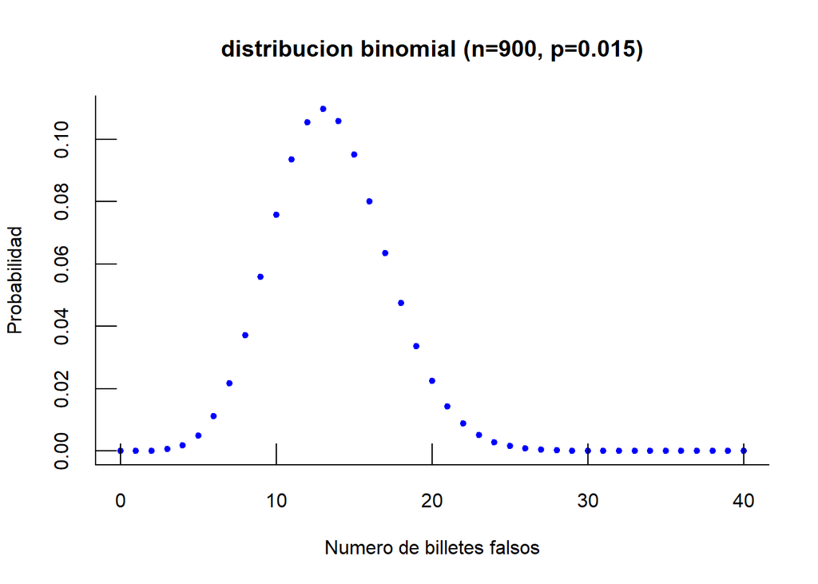

### Ejercicio 3

Según un estudio del Departamento Nacional de Estadística -DANE-, la vida media para el quinquenio de 2010 a 2015 de los habitantes de Colombia es 76 años, con una varianza de 25. Se pretende hacer un estudio con el objetivo de extrapolar los resultados anteriores a una pequeña ciudad de 100.000 habitantes, considerando que el tiempo de sobrevida es normal.

1. Cuántos de los habitantes de la pequeña ciudad superarán previsiblemente los 92 años
2. Cuántos vivirán menos de 55 años o más de 75 años

```
## [1] 0.0006871379
```

```
## [1] 1.334575e-05
```

```
## [1] 0.5792597
```

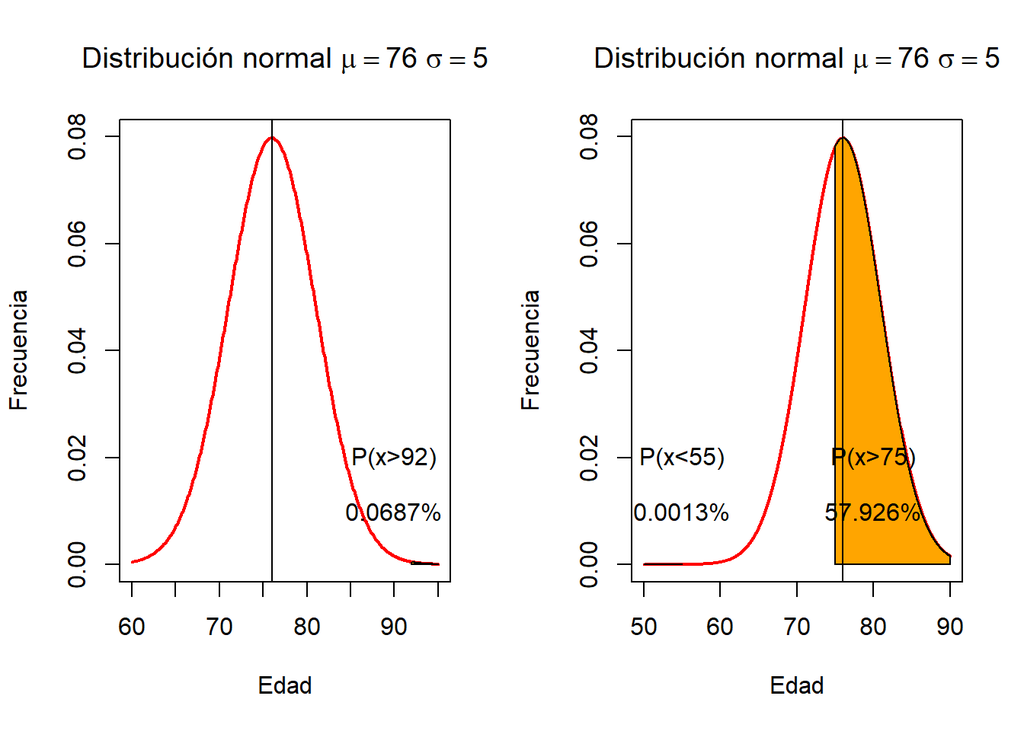

```
## [1] 57.92731
```

1. R/ El 0.0687% de la población superarán los 92 años
2. R/ Un 57.927% de la poblacion viviran 55 años o más de 75 años